# Prosper Loan Dataset Exploration

## by Oppong Samuel Addo

## Investigation Overview

> I chose to investigate the features that influences the default rate and the prosper score of loan applicants. In this presentation, we'll see how some of the faetures influence the tendency of default and also the performance of the prosper proprietory rating system.

## Key Insights for Presentation

> - Most loans are borrowed in order to consolidate debts.
> - The higher the income range, the higher the loan amount and the lesser the interest rate on the loan.
> - Comparing the loan amounts of defaulters and non defaulters, it was found that none of the defaulters borrowed loans up to `$30000` whiles that is not the case for non defaulters (there are values even greater than `$30000`). With this observation in mind, we can say that prosper did a good job issueing no outrageous amount of loans to defaulters.
> - The better the credit grade or prosper rating, the higher the loan amount borrowed. This means that borrowers with good credit grade or prosper rating tend to borrow large loan amount.
> - Performance of borrowers with grade `HR` (lowest grade) have increased tremendously. Comparing the pre-2009 with post-2009, it can be seen that the number of defaulters have dropped significantly. In pre-2009, number of defaulters exceeded the number of non defaulters whereas in post-2009, the number of defaulters is less than the number of non defaulters and this shows an improvement in borrowers with grade `HR`. Also, there is performance improvement in those with grade/rating of `AA` since there is drastic reduce in the number of defaulters over the years. In all, there is a decrease in the number of defaulters. This could mean that the company's rating systems was made much better after 2009 onwards.

## Dataset Overview

> This is an exploration of the prosper loan dataset which consists of 113937 rows and 81 columns(financial variables). This dataset contains the loan data of loan applicants and can be downloaded [here](https://www.kaggle.com/datasets/nurudeenabdulsalaam/prosper-loan-dataset) and the data dictionary(definition of variables) can be read [here](https://docs.google.com/spreadsheets/d/1gDyi_L4UvIrLTEC6Wri5nbaMmkGmLQBk-Yx3z0XDEtI/edit#gid=0).

#### What are some of the most Popular reasons for taking loan?

Most people take loan to consolidate debts.Poeple also do not disclose the reason for taking the loan which comes as the second most popular option for borrowers. There are other unknown reasons why people take loan as well and this is the third most popular choice of option for borrower when filing for loans. The fourth and fifth most popular choices of options are that, Some borrowers also take loans to do business and to also for Home Improvement.

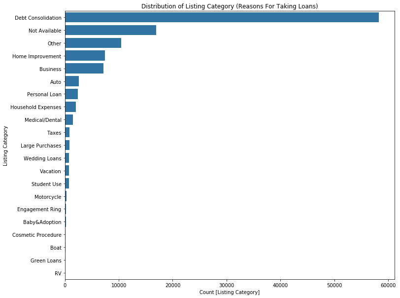

What is the interest rate on loans for the various groups of income ranges?

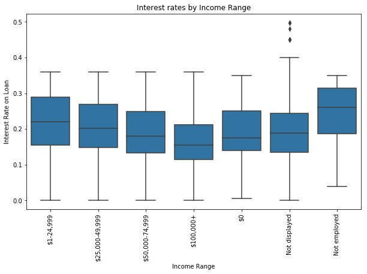

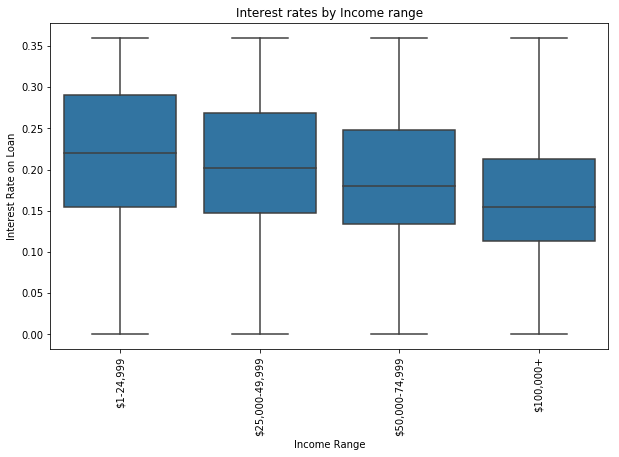

#### Is there a relationship between income range and loan amount?

There seems to be an increase in the median when we are moving from the least income range to a much high income range. This is clear, the higher the borrowers income range the higher the amount of loan they take and it makes sense. Also most borrowers take loan amounts within their income range and that perfectly understandable.

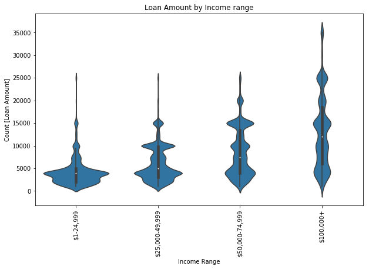

#### What is the relationship between interest rate and the loan amount?

Someway somehow, higher loan amounts tends to have lesser interest rate

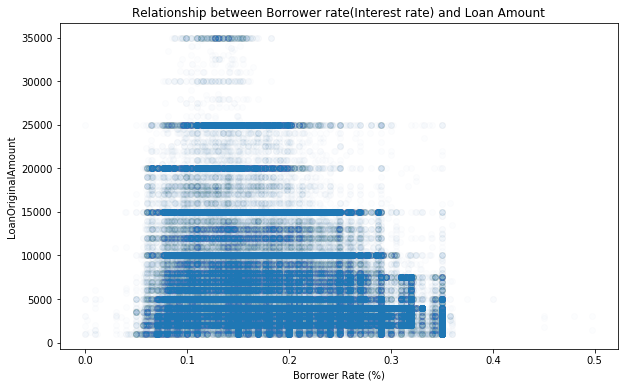

There is no significant relationship between the loan amount of those who defaulted and those who did not. With non defaulters having some few number of outrageous values beyound `$30000` whereas none of the defaulters borrowed up to `$30000`. Both have a median loan amount of `$5000`.

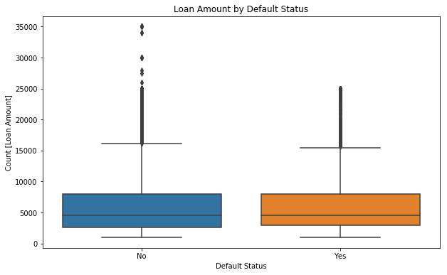

#### What is the relationship between the amount of loan and the credit grade or prosper rating?

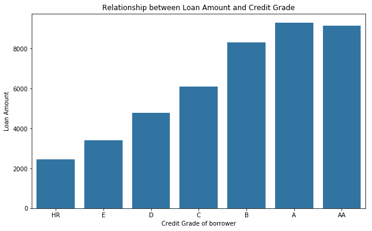

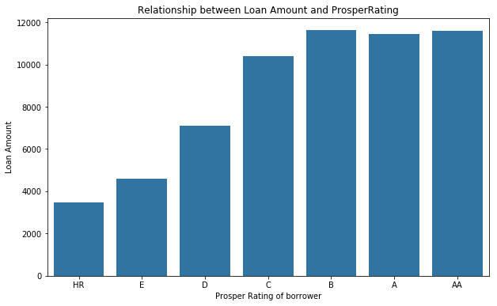

#### What is the performance in loan default?

Performance of borrowers with grade `HR` (lowest grade) have increased tremendously. Comparing the pre-2009 with post-2009, it can be seen that the number of defaulters have dropped significantly. In pre-2009, number of defaulters exceeded the number of non defaulters whereas in post-2009, the number of defaulters is less than the number of non defaulters and this shows an improvement in borrowers with grade `HR`. Also, there is performance improvement in those with grade/rating of `AA` since there is drastic reduce in the number of defaulters over the years. In all, there is a decrease in the number of defaulters. This could mean that the company's rating systems was made much better after 2009 onwards.

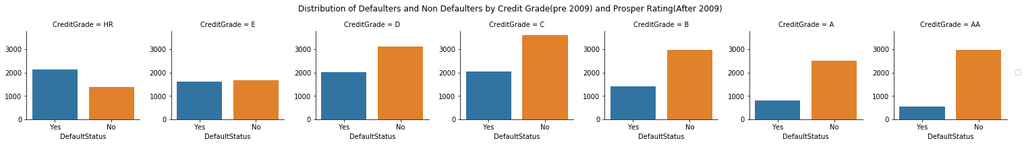

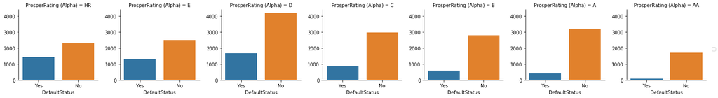